# Data Science in Practice Problem Set1

Group Members: Jingwei Chen, Ju-Hsuan Hsieh, Junze Li, Yunbei Wang

## Outlines

- 1.Background
- 2.Exploratory Data Analysis(EDA)
  - 2.1 Missing Values Detection and Data Type Correction
  - 2.2 Univariate Analysis
  - 2.3 Multivariate Analysis
- 3.Data Pre-processing
  - 3.1 Outlier Checking
  - 3.2 One-Hot Encoding
  - 3.3 Normalization
- 4.Feature Analysis
- 5.Segmentation of Customers

```python
import numpy as np
import pandas as pd
import matplotlib.pyplot as plt
import seaborn as sns
from sklearn.ensemble import RandomForestRegressor
from sklearn.cluster import KMeans
from matplotlib.colors import ListedColormap
from sklearn.preprocessing import StandardScaler
import warnings
warnings.filterwarnings("ignore")
```

```python
customers_data = pd.read_csv('customers.csv')
active_customers_data = customers_data[customers_data['Churn']=='No']
```

```python
print('There are {} customers totally and {} customers are still active.'.format(len(customers_data), len(active_customers_data)))
```

```
There are 7043 customers totally and 5174 customers are still active.
```

Based on the description of this problem, we only focus on the customers who do not leave the company from now on.

```python
active_customers_data.head()
```

|  | customerID | gender | SeniorCitizen | Partner | Dependents | tenure | PhoneService | MultipleLines | InternetService | OnlineSecurity | ... | DeviceProtection | TechSupport | StreamingTV | StreamingMovies | Contract | PaperlessBilling | PaymentMethod | MonthlyCharges | TotalCharges | Churn |
| --- | --- | --- | --- | --- | --- | --- | --- | --- | --- | --- | --- | --- | --- | --- | --- | --- | --- | --- | --- | --- | --- |
| 0 | 7590-VHVEG | Female | 0 | Yes | No | 1 | No | No phone service | DSL | No | ... | No | No | No | No | Month-to-month | Yes | Electronic check | 29.85 | 29.85 | No |
| 1 | 5575-GNVDE | Male | 0 | No | No | 34 | Yes | No | DSL | Yes | ... | Yes | No | No | No | One year | No | Mailed check | 56.95 | 1889.5 | No |
| 3 | 7795-CFOCW | Male | 0 | No | No | 45 | No | No phone service | DSL | Yes | ... | Yes | Yes | No | No | One year | No | Bank transfer (automatic) | 42.30 | 1840.75 | No |
| 6 | 1452-KIOVK | Male | 0 | No | Yes | 22 | Yes | Yes | Fiber optic | No | ... | No | No | Yes | No | Month-to-month | Yes | Credit card (automatic) | 89.10 | 1949.4 | No |
| 7 | 6713-OKOMC | Female | 0 | No | No | 10 | No | No phone service | DSL | Yes | ... | No | No | No | No | Month-to-month | No | Mailed check | 29.75 | 301.9 | No |

5 rows × 21 columns

```python
active_customers_data.dtypes
```

```
customerID           object
gender               object
SeniorCitizen         int64
Partner              object
Dependents           object
tenure                int64
PhoneService         object
MultipleLines        object
InternetService      object
OnlineSecurity       object
OnlineBackup         object
DeviceProtection     object
TechSupport          object
StreamingTV          object
StreamingMovies      object
Contract             object
PaperlessBilling     object
PaymentMethod        object
MonthlyCharges      float64
TotalCharges         object
Churn                object
dtype: object
```

```python
active_customers_data.describe()
```

|  | SeniorCitizen | tenure | MonthlyCharges |
| --- | --- | --- | --- |
| count | 5174.000000 | 5174.000000 | 5174.000000 |
| mean | 0.128721 | 37.569965 | 61.265124 |
| std | 0.334923 | 24.113777 | 31.092648 |
| min | 0.000000 | 0.000000 | 18.250000 |
| 25% | 0.000000 | 15.000000 | 25.100000 |
| 50% | 0.000000 | 38.000000 | 64.425000 |
| 75% | 0.000000 | 61.000000 | 88.400000 |
| max | 1.000000 | 72.000000 | 118.750000 |

### 1. Background

Customer churn is a term used especially in the world of subscription based businesses to describe loss of customers.

Churn is important because it directly affects your service's profitability. It is common to assume that the profitability of a service is directly related to the growth of its customer base. That might lead business owners to imply that in order to grow their customer base, the rate of acquiring new customers must exceed the churn rate.

In order to answers the questions "Are we losing customers?" and "If so, how?", our team made a Churn Analysis to support the Management to take action.

### 2. Exploratory Data Analysis(EDA)

In this part, we explore the attributes of different data types initially, based on the statistic properties and the relationship between different attributes.

#### 2.1 Missing Values Detection and Data Type Correction

Firstly, we find if there is any null values in the dataframe.

```python
active_customers_data.isnull().any().any()
```

```
False
```

Although there is no missing value in the dataframe, the data type of the "TotalCharges" is object, which means that there should be some value that is not a float.

```python
active_customers_data.TotalCharges.min()
```

```
' '
```

```python
empty_values = len(active_customers_data[active_customers_data["TotalCharges"] == ' '])
print('There are {} empty values in the TotalCharges column.'.format(empty_values))
```

```
There are 11 empty values in the TotalCharges column.
```

Then we set the empty values in "TotalCharges" to Nan and change its data type into "float32". We also notice that the data type of "SeniorCitizen" should not be "int64", so we change it into "object".

```python
active_customers_data["SeniorCitizen"]=active_customers_data["SeniorCitizen"].astype("object")
active_customers_data["TotalCharges"] = active_customers_data["TotalCharges"].replace(" ", np.nan).astype('float32')
```

```python
active_customers_data.dtypes
```

```
customerID           object
gender               object
SeniorCitizen        object
Partner              object
Dependents           object
tenure                int64
PhoneService         object
MultipleLines        object
InternetService      object
OnlineSecurity       object
OnlineBackup         object
DeviceProtection     object
TechSupport          object
StreamingTV          object
StreamingMovies      object
Contract             object
PaperlessBilling     object
PaymentMethod        object
MonthlyCharges      float64
TotalCharges        float32
Churn                object
dtype: object
```

Here, each attribute has a proper data type, and we can find the description of numerical and categorical attributes respectively in the following tables.

```python
active_customers_data.describe() # the description of the numerical data
```

|  | tenure | MonthlyCharges | TotalCharges |
| --- | --- | --- | --- |
| count | 5174.000000 | 5174.000000 | 5163.000000 |
| mean | 37.569965 | 61.265124 | 2555.345459 |
| std | 24.113777 | 31.092648 | 2329.457764 |
| min | 0.000000 | 18.250000 | 18.799999 |
| 25% | 15.000000 | 25.100000 | 577.825012 |
| 50% | 38.000000 | 64.425000 | 1683.599976 |
| 75% | 61.000000 | 88.400000 | 4264.125000 |
| max | 72.000000 | 118.750000 | 8672.450195 |

```python
active_customers_data.describe(include=['O']) # the description of the categorical data
```

|  | customerID | gender | SeniorCitizen | Partner | Dependents | PhoneService | MultipleLines | InternetService | OnlineSecurity | OnlineBackup | DeviceProtection | TechSupport | StreamingTV | StreamingMovies | Contract | PaperlessBilling | PaymentMethod | Churn |
| --- | --- | --- | --- | --- | --- | --- | --- | --- | --- | --- | --- | --- | --- | --- | --- | --- | --- | --- |
| count | 5174 | 5174 | 5174 | 5174 | 5174 | 5174 | 5174 | 5174 | 5174 | 5174 | 5174 | 5174 | 5174 | 5174 | 5174 | 5174 | 5174 | 5174 |
| unique | 5174 | 2 | 2 | 2 | 2 | 2 | 3 | 3 | 3 | 3 | 3 | 3 | 3 | 3 | 3 | 2 | 4 | 1 |
| top | 4020-KIUDI | Male | 0 | Yes | No | Yes | No | DSL | No | Yes | No | No | Yes | Yes | Month-to-month | Yes | Mailed check | No |
| freq | 1 | 2625 | 4508 | 2733 | 3390 | 4662 | 2541 | 1962 | 2037 | 1906 | 1884 | 2027 | 1893 | 1914 | 2220 | 2771 | 1304 | 5174 |

Because there are only 11 NaN values in the dataframe and these values are difficult to be fixed, we drop those rows including NaN values in the following analysis.

```python
active_customers_data = active_customers_data[active_customers_data["TotalCharges"].notnull()]
```

#### 2.2 Univariate Analysis

As the colleage is interested in the lifetime value of the customers, we set the index **MonthlyCharges** as the variable we want to analyse in detail.

Firstly, we plot the box plot of each categorical features with regard to **MonthlyCharges**. Using the kind="boxen", we can observe the distribution of the data points.

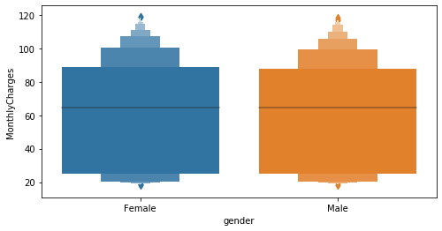

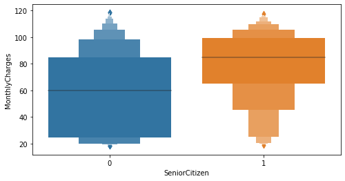

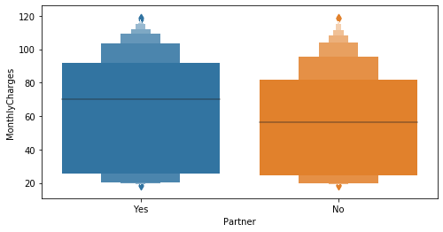

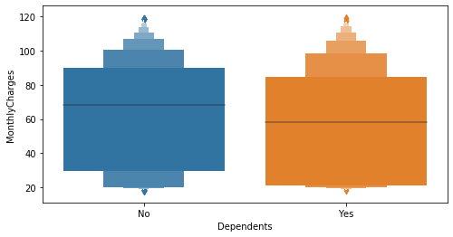

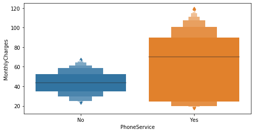

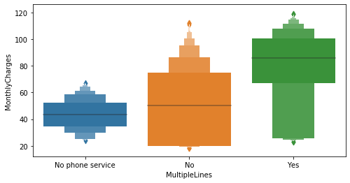

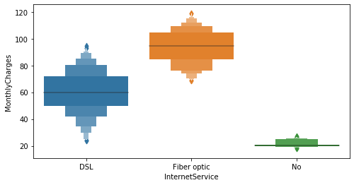

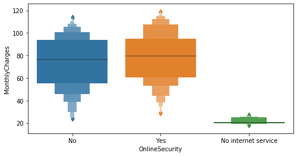

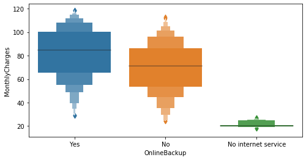

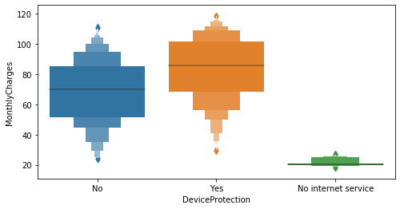

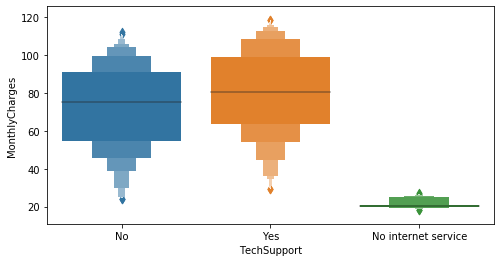

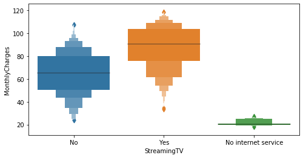

[5 more figures not shown]

```python
active_customers_data_withoutID=active_customers_data.drop(columns="customerID")
for column in active_customers_data_withoutID.columns:
    if active_customers_data_withoutID[column].dtype == "O":
        fig,ax=plt.subplots(figsize=(8,4))
        sns.catplot(y="MonthlyCharges",x=column,data=active_customers_data_withoutID,kind="boxen",ax=ax)
        plt.close()
```

Next, for numerial attributes, we plot the histogram of them.

##### Tenure

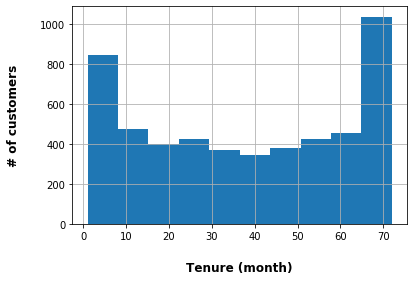

```python
ax = active_customers_data_withoutID.hist(column='tenure', bins = 10)
ax = ax[0]
for x in ax:
    x.set_title("")
    x.set_xlabel("Tenure (month)", labelpad=20, weight='bold', size=12)
    x.set_ylabel("# of customers", labelpad=20, weight='bold', size=12)
```

We can observe from the histogram that over 800 customers are quite new to the company, which they have close to zero and under 10 months of tenure. At the same time, there are over 1000 customers that have been suscribed to the companies' services for nearly 70 months. For the other duraitons of tenure, the distribution is quite uniform.

##### MonthlyCharges

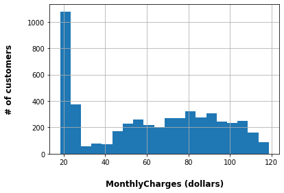

```python
ax = active_customers_data_withoutID.hist(column='MonthlyCharges', bins = 20)
ax = ax[0]
for x in ax:
    x.set_title("")
    x.set_xlabel("MonthlyCharges (dollars)", labelpad=20, weight='bold', size=12)
    x.set_ylabel("# of customers", labelpad=20, weight='bold', size=12)
```

We can observe from the histogram of MonthlyCharges that over 1000 customers are charged around only 20 dollars each months, where there is a gap between charges under 30 and over 40 dollars.

##### TotalCharges

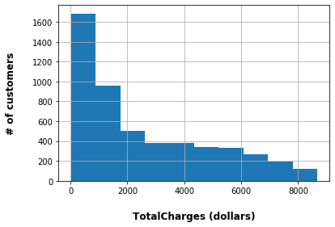

```python
ax = active_customers_data_withoutID.hist(column='TotalCharges', bins = 10)
ax = ax[0]
for x in ax:
    x.set_title("")
    x.set_xlabel("TotalCharges (dollars)", labelpad=20, weight='bold', size=12)
    x.set_ylabel("# of customers", labelpad=20, weight='bold', size=12)
```

From the histogram of the TotalCharges, we can see that about 1600 customers have been charged under 1000 in total.

#### 2.3 Multivariate Analysis

##### InternetService & PhoneService

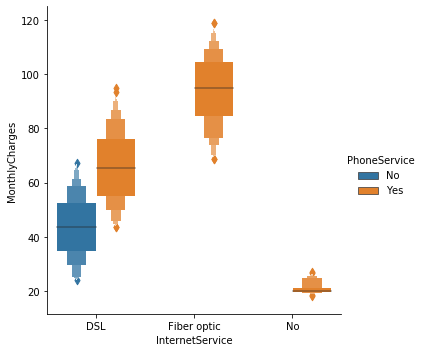

```python
sns.catplot(x="InternetService", y="MonthlyCharges", hue="PhoneService", kind="boxen", data=active_customers_data_withoutID);
```

From this plot, we can see that customers with fiber optics are charged the most, which they all have phone services also. And of course, customers with DSL and phone services pay more than the one than don't have.

##### DSL clients

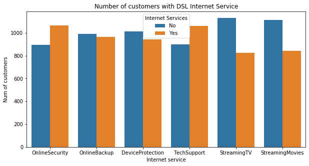

```python
DSL_clients = active_customers_data_withoutID[active_customers_data_withoutID.InternetService == "DSL"]
cols = ["OnlineSecurity", "OnlineBackup", "DeviceProtection", "TechSupport", "StreamingTV", "StreamingMovies"]
data_melt = pd.melt(DSL_clients[cols]).rename({'value': 'Internet Services'}, axis = 1)
plt.figure(figsize=(10, 5))
ax = sns.countplot(data=data_melt, x='variable', hue='Internet Services')
ax.set(xlabel='Internet service', ylabel='Num of customers')
plt.title("Number of customers with DSL Internet Service")
plt.show()
```

##### Fiber optic clients

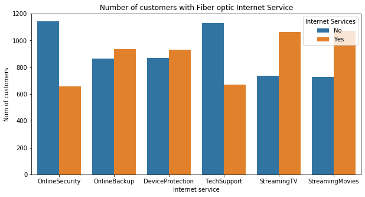

```python
Fiber_clients = active_customers_data_withoutID[active_customers_data_withoutID.InternetService == "Fiber optic"]
cols = ["OnlineSecurity", "OnlineBackup", "DeviceProtection", "TechSupport", "StreamingTV", "StreamingMovies"]
data_melt = pd.melt(Fiber_clients[cols]).rename({'value': 'Internet Services'}, axis = 1)
plt.figure(figsize=(10, 5))
ax = sns.countplot(data=data_melt, x='variable', hue='Internet Services')
ax.set(xlabel='Internet service', ylabel='Num of customers')
plt.title("Number of customers with Fiber optic Internet Service")
plt.show()
```

### 3. Data Pre-processing

#### 3.1 Outlier Checking

```python
#MonthlyCharges outlier checking
Q1_MonthlyCharges = active_customers_data['MonthlyCharges'].quantile(.25)
Q3_MonthlyCharges = active_customers_data['MonthlyCharges'].quantile(.75)
q1_MonthlyCharges = Q1_MonthlyCharges-1.5*(Q3_MonthlyCharges-Q1_MonthlyCharges)
q3_MonthlyCharges = Q3_MonthlyCharges+1.5*(Q3_MonthlyCharges-Q1_MonthlyCharges)
active_customers_data = active_customers_data[active_customers_data['MonthlyCharges'].between(q1_MonthlyCharges, q3_MonthlyCharges)]
print('There is %d outlier of MonthlyCharges.'%(len(active_customers_data['MonthlyCharges'])-5163))
```

```
There is 0 outlier of MonthlyCharges.
```

```python
#tenure outlier checking
Q1_tenure = active_customers_data['tenure'].quantile(.25)
Q3_tenure = active_customers_data['tenure'].quantile(.75)
q1_tenure = Q1_tenure-1.5*(Q3_tenure-Q1_tenure)
q3_tenure = Q3_tenure+1.5*(Q3_tenure-Q1_tenure)
active_customers_data = active_customers_data[active_customers_data['tenure'].between(q1_tenure, q3_tenure)]
print('There is %d outlier of tenure.'%(len(active_customers_data['tenure'])-5163))
```

```
There is 0 outlier of tenure.
```

#### 3.2 One-hot Encoding

Since the **customerID** and **Churn** are useless for the following analysis, we drop these two attributes.

```python
active_customers_data = active_customers_data.drop(columns = ['customerID', 'Churn'], axis = 1)
```

Then we observe the unique values of each categorical variable.

```python
# detail information about categorial data
for col in active_customers_data.columns:
    if active_customers_data[col].dtype == 'O':
        print(col, active_customers_data[col].unique())
```

```
gender ['Female' 'Male']
SeniorCitizen [0 1]
Partner ['Yes' 'No']
Dependents ['No' 'Yes']
PhoneService ['No' 'Yes']
MultipleLines ['No phone service' 'No' 'Yes']
InternetService ['DSL' 'Fiber optic' 'No']
OnlineSecurity ['No' 'Yes' 'No internet service']
OnlineBackup ['Yes' 'No' 'No internet service']
DeviceProtection ['No' 'Yes' 'No internet service']
TechSupport ['No' 'Yes' 'No internet service']
StreamingTV ['No' 'Yes' 'No internet service']
StreamingMovies ['No' 'No internet service' 'Yes']
Contract ['Month-to-month' 'One year' 'Two year']
PaperlessBilling ['Yes' 'No']
PaymentMethod ['Electronic check' 'Mailed check' 'Bank transfer (automatic)'
 'Credit card (automatic)']
```

For the attributes with binary values, we set 0 and 1 to distinct the different values. For the other attributes, we dummy them into several columns.

```python
# convert categorical data to numerical data

# for binary category, convert them to '0', '1'

active_customers_data['Female'] = active_customers_data['gender'].apply(lambda x: 1 if x=='Female' else 0)
active_customers_data = active_customers_data.drop(columns='gender')

active_customers_data['SeniorCitizen'] = active_customers_data['SeniorCitizen'].astype('int64')

# we regard the category 'no internet service' as 'no'
binary_cate = ['Partner', 'Dependents', 'PhoneService', 'MultipleLines', 'OnlineSecurity', 'OnlineBackup', 'DeviceProtection', 'TechSupport', 'StreamingTV', 'StreamingMovies', 'PaperlessBilling']
for cate in binary_cate:
    active_customers_data[cate] = active_customers_data[cate].apply(lambda x: 1 if x=='Yes' else 0)

# for the rest features, we use one-hot code
def dummies(col,df):
    dummies = pd.get_dummies(df[col], prefix=col)
    df = pd.concat([df, dummies], axis=1)
    df = df.drop(columns=col)
    return df

active_customers_data = dummies('InternetService', active_customers_data)
active_customers_data = dummies('Contract', active_customers_data)
active_customers_data = dummies('PaymentMethod', active_customers_data)
```

```python
active_customers_data
```

|  | SeniorCitizen | Partner | Dependents | tenure | PhoneService | MultipleLines | OnlineSecurity | OnlineBackup | DeviceProtection | TechSupport | ... | InternetService_DSL | InternetService_Fiber optic | InternetService_No | Contract_Month-to-month | Contract_One year | Contract_Two year | PaymentMethod_Bank transfer (automatic) | PaymentMethod_Credit card (automatic) | PaymentMethod_Electronic check | PaymentMethod_Mailed check |
| --- | --- | --- | --- | --- | --- | --- | --- | --- | --- | --- | --- | --- | --- | --- | --- | --- | --- | --- | --- | --- | --- |
| 0 | 0 | 1 | 0 | 1 | 0 | 0 | 0 | 1 | 0 | 0 | ... | 1 | 0 | 0 | 1 | 0 | 0 | 0 | 0 | 1 | 0 |
| 1 | 0 | 0 | 0 | 34 | 1 | 0 | 1 | 0 | 1 | 0 | ... | 1 | 0 | 0 | 0 | 1 | 0 | 0 | 0 | 0 | 1 |
| 3 | 0 | 0 | 0 | 45 | 0 | 0 | 1 | 0 | 1 | 1 | ... | 1 | 0 | 0 | 0 | 1 | 0 | 1 | 0 | 0 | 0 |
| 6 | 0 | 0 | 1 | 22 | 1 | 1 | 0 | 1 | 0 | 0 | ... | 0 | 1 | 0 | 1 | 0 | 0 | 0 | 1 | 0 | 0 |
| 7 | 0 | 0 | 0 | 10 | 0 | 0 | 1 | 0 | 0 | 0 | ... | 1 | 0 | 0 | 1 | 0 | 0 | 0 | 0 | 0 | 1 |
| ... | ... | ... | ... | ... | ... | ... | ... | ... | ... | ... | ... | ... | ... | ... | ... | ... | ... | ... | ... | ... | ... |
| 7037 | 0 | 0 | 0 | 72 | 1 | 0 | 0 | 0 | 0 | 0 | ... | 0 | 0 | 1 | 0 | 0 | 1 | 1 | 0 | 0 | 0 |
| 7038 | 0 | 1 | 1 | 24 | 1 | 1 | 1 | 0 | 1 | 1 | ... | 1 | 0 | 0 | 0 | 1 | 0 | 0 | 0 | 0 | 1 |
| 7039 | 0 | 1 | 1 | 72 | 1 | 1 | 0 | 1 | 1 | 0 | ... | 0 | 1 | 0 | 0 | 1 | 0 | 0 | 1 | 0 | 0 |
| 7040 | 0 | 1 | 1 | 11 | 0 | 0 | 1 | 0 | 0 | 0 | ... | 1 | 0 | 0 | 1 | 0 | 0 | 0 | 0 | 1 | 0 |
| 7042 | 0 | 0 | 0 | 66 | 1 | 0 | 1 | 0 | 1 | 1 | ... | 0 | 1 | 0 | 0 | 0 | 1 | 1 | 0 | 0 | 0 |

5163 rows × 26 columns

#### 3.3 Normalization

Here we will use The Min-Max scaler to perform normalization. It was chosen because the dataset was not affected by outlier as we discussed before.

```python
active_customers_data['MonthlyCharges'] = (active_customers_data['MonthlyCharges'] - active_customers_data['MonthlyCharges'].min()) \
/ (active_customers_data['MonthlyCharges'].max() - active_customers_data['MonthlyCharges'].min())

active_customers_data['tenure'] = (active_customers_data['tenure'] - active_customers_data['tenure'].min()) \
/ (active_customers_data['tenure'].max() - active_customers_data['tenure'].min())


active_customers_data
```

|  | SeniorCitizen | Partner | Dependents | tenure | PhoneService | MultipleLines | OnlineSecurity | OnlineBackup | DeviceProtection | TechSupport | ... | InternetService_DSL | InternetService_Fiber optic | InternetService_No | Contract_Month-to-month | Contract_One year | Contract_Two year | PaymentMethod_Bank transfer (automatic) | PaymentMethod_Credit card (automatic) | PaymentMethod_Electronic check | PaymentMethod_Mailed check |
| --- | --- | --- | --- | --- | --- | --- | --- | --- | --- | --- | --- | --- | --- | --- | --- | --- | --- | --- | --- | --- | --- |
| 0 | 0 | 1 | 0 | 0.000000 | 0 | 0 | 0 | 1 | 0 | 0 | ... | 1 | 0 | 0 | 1 | 0 | 0 | 0 | 0 | 1 | 0 |
| 1 | 0 | 0 | 0 | 0.464789 | 1 | 0 | 1 | 0 | 1 | 0 | ... | 1 | 0 | 0 | 0 | 1 | 0 | 0 | 0 | 0 | 1 |
| 3 | 0 | 0 | 0 | 0.619718 | 0 | 0 | 1 | 0 | 1 | 1 | ... | 1 | 0 | 0 | 0 | 1 | 0 | 1 | 0 | 0 | 0 |
| 6 | 0 | 0 | 1 | 0.295775 | 1 | 1 | 0 | 1 | 0 | 0 | ... | 0 | 1 | 0 | 1 | 0 | 0 | 0 | 1 | 0 | 0 |
| 7 | 0 | 0 | 0 | 0.126761 | 0 | 0 | 1 | 0 | 0 | 0 | ... | 1 | 0 | 0 | 1 | 0 | 0 | 0 | 0 | 0 | 1 |
| ... | ... | ... | ... | ... | ... | ... | ... | ... | ... | ... | ... | ... | ... | ... | ... | ... | ... | ... | ... | ... | ... |
| 7037 | 0 | 0 | 0 | 1.000000 | 1 | 0 | 0 | 0 | 0 | 0 | ... | 0 | 0 | 1 | 0 | 0 | 1 | 1 | 0 | 0 | 0 |
| 7038 | 0 | 1 | 1 | 0.323944 | 1 | 1 | 1 | 0 | 1 | 1 | ... | 1 | 0 | 0 | 0 | 1 | 0 | 0 | 0 | 0 | 1 |
| 7039 | 0 | 1 | 1 | 1.000000 | 1 | 1 | 0 | 1 | 1 | 0 | ... | 0 | 1 | 0 | 0 | 1 | 0 | 0 | 1 | 0 | 0 |
| 7040 | 0 | 1 | 1 | 0.140845 | 0 | 0 | 1 | 0 | 0 | 0 | ... | 1 | 0 | 0 | 1 | 0 | 0 | 0 | 0 | 1 | 0 |
| 7042 | 0 | 0 | 0 | 0.915493 | 1 | 0 | 1 | 0 | 1 | 1 | ... | 0 | 1 | 0 | 0 | 0 | 1 | 1 | 0 | 0 | 0 |

5163 rows × 26 columns

### 4. Feature Analysis

We explore the most important feature regarding to **tenure** and **MonthlyCharges** respectively, based on random forest regressor, which is proper for categorical data.

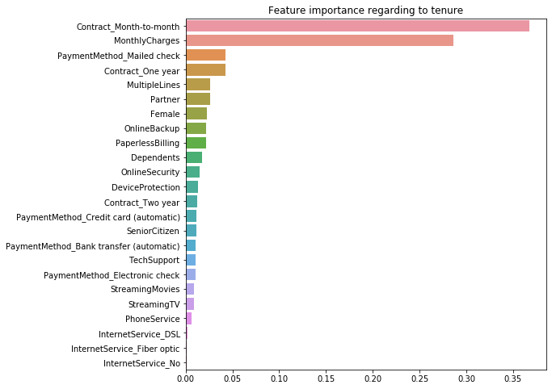

```python
# tenure
x,y = active_customers_data.drop(columns=['tenure','TotalCharges']), active_customers_data['tenure']
reg_tenure = RandomForestRegressor(random_state=8, n_jobs=-1)
reg_tenure = reg_tenure.fit(x,y)

feature_import = pd.Series(data=reg_tenure.feature_importances_, index=x.columns).sort_values(ascending=False)
plt.figure(figsize=(8,8))
plt.title('Feature importance regarding to tenure')
sns.barplot(y=feature_import.index, x=feature_import.values)
plt.show()
```

From the figure above, we can find that **Contract_Month-to-Month** and **MonthlyCharges** are the most two important features to predict the **tenure**.

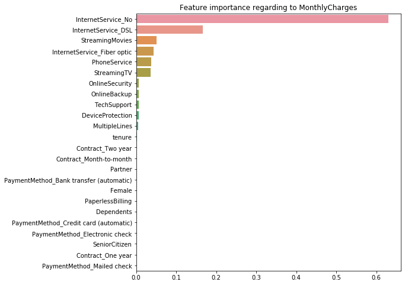

```python
# MonthlyCharges
x,y = active_customers_data.drop(columns=['MonthlyCharges','TotalCharges']), active_customers_data['MonthlyCharges']
reg_monthlycharges = RandomForestRegressor(random_state=8, n_jobs=-1)
reg_monthlycharges = reg_monthlycharges.fit(x,y)

feature_import = pd.Series(data=reg_monthlycharges.feature_importances_, index=x.columns).sort_values(ascending=False)
plt.figure(figsize=(8,8))
plt.title('Feature importance regarding to MonthlyCharges')
sns.barplot(y=feature_import.index, x=feature_import.values)
plt.show()
```

From the figure above, we can find that **InternetService_No** and **InternetService_DSL** are the most two important features to predict the **MonthlyCharges**.

### 5. Segmentation of Customers

As we do not have the labels for the segmentation of customers, we choose K-means clustering algorithm to separate customers.

```python
data_norm = active_customers_data
data_norm[['tenure', 'MonthlyCharges', 'TotalCharges']] = StandardScaler().fit_transform(active_customers_data[['tenure', 'MonthlyCharges', 'TotalCharges']])
cluster_kmeans = KMeans(n_clusters=3, random_state=8, max_iter=500)
label = cluster_kmeans.fit_predict(data_norm)
```

```python
x,y = active_customers_data['MonthlyCharges'],active_customers_data['tenure']
color_dict = ListedColormap(sns.color_palette("Pastel2").as_hex())
```

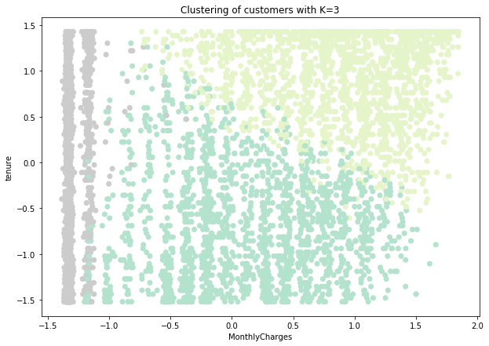

```python
plt.figure(figsize=[10, 7])
plt.title('Clustering of customers with K=3')
plt.xlabel('MonthlyCharges')
plt.ylabel('tenure')
plt.scatter(x, y, c=label, cmap=color_dict)
plt.show()
```